# MLP

## Introduction to Artifical Neural Networks with Kera

#### Perceptron

- Based on artifical neurons, the inputs and output are numbers, and each input connection is associated with a weight
- Perceptron is composed of a single layer of Threshold Logic Unit (TLUs), with each TLU connected to all the inputs
- Fully Connected Layer, or Dense Layer
  - All the neurons in a layer are connected to every neuron in the previous layer
- The decision boundary is linear
- Hebb's rule
  - fed one training instance at a time
  - for every output neuron that produced a wrong prediction, reinforces the connection weights from the inputs that would have contriubted to the correct prediction
- Do not output a class probability; rather, Perceptron classifier makes predictions based on a hard threshold
- Cannot solve Exclusive OR as any other linear classification models

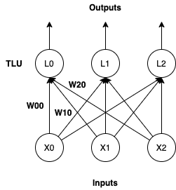

```python
from IPython.display import Image
Image(filename='img/Perceptron.png')
```

$$ X = |X_{0} X_{1} X_{2}|$$$$ W = \begin{bmatrix} w_{00} & w_{01} & w_{02} \\ w_{10} & w_{11} & w_{12} \\ w_{20} & w_{21} & w_{22} \end{bmatrix}$$

$w_{ij}$, i, index in layer 0, j, index in layer 1

$$ L = |L_{0} L_{1} L_{2}|$$$$ L = XW $$$$ Outputs = \phi (L) $$

$\phi$ is called the activation function

```python
import numpy as np
from sklearn.datasets import load_iris
from sklearn.linear_model import Perceptron

iris = load_iris() # Bunch
x = iris.data[:, (2, 3)]
y = (iris.target == 0).astype(np.int)

per_clf = Perceptron()
per_clf.fit(x, y)

y_pred = per_clf.predict([[2, 0.5]])
```

#### Multilayer Perceptron (MLP)

- Stack multiple Perceptrons
- One input layer, one or more hidden layers of TLUs, one output layer
- Gradient Descent steps
  - for each training instance, make a prediction and measures the error
  - goes through each layer in reverse to measure the error contribution from each connection
  - tweaks the connection weights to reduce the error
- Keras model can be used just like regular layers
- Calling the fit() method again, Keras will continue traiing where it left off
- Transfer Learning
  - resue the lower layers of the previous network

#### Regression MLPs

- For output neurons
  - No activation function, free to output any range of values
  - ReLU, the output is always positive
  - Softplus, $softplus(z) = log(1+exp(z))$, a smooth variant of ReLU, close to 0 when z is negative, close to z when z is positive
  - Logistic function or hyperbolic tangent, then scale to the appropriate range, within a given range of values
- Loss function
  - Mean squared error (MSE)
  - Mean absolute error (MAE), if have a lot of outliers
  - Huber loss, a combination of both
- Architecture
  - input neurons, one per input feature
  - hidden layers, depends on the problems, typically 1 to 5
  - neurons per hidden layer, depend on the problem, typically 10 to 100
  - output neurons, 1 per prediction dimension
  - Hidden activation, ReLU or SELU
  - Output activation, none, or ReLU/softplus
  - Loss function, MSE, MAE, or Huber

```python
from sklearn.datasets import fetch_california_housing
from sklearn.model_selection import train_test_split
from sklearn.preprocessing import StandardScaler

housing = fetch_california_housing()

X_train_full, X_test, y_train_full, y_test = train_test_split(housing.data, housing.target, random_state=42)
X_train, X_valid, y_train, y_valid = train_test_split(X_train_full, y_train_full, random_state=42)

scaler = StandardScaler()
X_train = scaler.fit_transform(X_train)
X_valid = scaler.transform(X_valid)
X_test = scaler.transform(X_test)
```

```python
import tensorflow as tf
from tensorflow import keras

model = keras.models.Sequential()
model.add(keras.Input(shape=(8,))) # recommend to specify the input_shape in the first layer
model.add(keras.layers.Dense(30, activation="relu",))
model.add(keras.layers.Dense(1))
```

```python
model.compile(loss="mean_squared_error", optimizer=keras.optimizers.SGD(lr=1e-3))
```

```python
history = model.fit(X_train, y_train, epochs=20, validation_data=(X_valid, y_valid))

mse_test = model.evaluate(X_test, y_test)

y_pred = model.predict(X_test[:3])
```

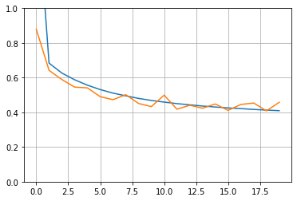

```python
plt.plot(pd.DataFrame(history.history))
plt.grid(True)
plt.gca().set_ylim(0, 1)
plt.show()
```

#### Classification MLPs

- Output is between 0 and 1, which you can interpret as the estimated probability of the positive class
- Dedicate one output neuron for each positive class, the probabilities do not necessarily add up to 1
- Softmax activaton is used as the activation function for the output layer to ensure estimated probabilities are betweenn 0 and 1, and they add up to 1

$$ \sigma(z)_{i} = \frac{e^{z_{i}}}{\Sigma^{k}_{j=1} e^{z_{j}}} $$

- Architecture
  - input and hidden layers, same as regression
  - # output neurons 1 per class
  - output layer activation
    - binary, logistic
    - multilabel binary, logistic
    - multiclass, softmax, which makes all estimated probabilites are between 0 and 1 and that they add up to 1
  - Loss function, cross-entropy

```python
import tensorflow as tf
from tensorflow import keras
```

```python
fashion_mnist = keras.datasets.fashion_mnist
(X_train, y_train), (X_test, y_test) = fashion_mnist.load_data()
```

```python
X_train.shape, y_train.shape, X_test.shape, y_test.shape
```

```
((60000, 28, 28), (60000,), (10000, 28, 28), (10000,))
```

```python
X_valid, X_train = X_train[:5000] / 255., X_train[5000:] / 255.
y_valid, y_train = y_train[:5000], y_train[5000:]
X_test = X_test / 255.
```

```python
model = keras.models.Sequential()
model.add(keras.layers.Flatten(input_shape=[28, 28])) # convert input image into a 1D array
model.add(keras.layers.Dense(300, activation='relu')) # contain connection weights between neurons and their inputs, bias
model.add(keras.layers.Dense(100, activation='relu'))
model.add(keras.layers.Dense(10, activation='softmax'))
```

```python
model.summary() # layer's name, shape, number of parameters
# 785*300, 784 feature + 1 bias
# 301*100
# 101*10
```

```
Model: "sequential_2"
_________________________________________________________________
Layer (type)                 Output Shape              Param #
=================================================================
flatten_1 (Flatten)          (None, 784)               0
_________________________________________________________________
dense_11 (Dense)             (None, 300)               235500
_________________________________________________________________
dense_12 (Dense)             (None, 100)               30100
_________________________________________________________________
dense_13 (Dense)             (None, 10)                1010
=================================================================
Total params: 266,610
Trainable params: 266,610
Non-trainable params: 0
_________________________________________________________________
```

```python
model.layers[1].name
```

```
'dense_11'
```

```python
weights, biases = model.layers[1].get_weights()
print(weights.shape) # 784*300
print(biases.shape) # 300
```

```
(784, 300)
(300,)
```

```python
# specify the loss function and the optimizer
# sparse_categorical_crossentropy, 1 label for each record
# categorical_crossentropy, 10 probabilities to represent label
# binary_crossentropy, binary classification
model.compile(loss='sparse_categorical_crossentropy', optimizer='sgd', metrics=['accuracy'])
```

```python
# Calling fit() method again will continue training where it left off
# validation error is computed at the end of each epoch
# training error is computed during each epoch
history = model.fit(X_train, y_train, epochs=30, validation_data=(X_valid, y_valid))
```

```python
history.params
```

```
{'verbose': 1, 'epochs': 30, 'steps': 1719}
```

```python
import pandas as pd
import matplotlib.pyplot as plt
```

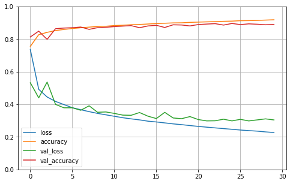

```python
pd.DataFrame(history.history).plot(figsize=(8, 5))
plt.grid(True)
plt.gca().set_ylim(0, 1)
plt.show()
```

```python
model.evaluate(X_test, y_test)
```

```
[0.336931973695755, 0.8809999823570251]
```

```python
y_prob = model.predict(X_test[:3])
y_prob.round(2)
```

```
array([[0.  , 0.  , 0.  , 0.  , 0.  , 0.01, 0.  , 0.02, 0.  , 0.97],
       [0.  , 0.  , 0.99, 0.  , 0.01, 0.  , 0.  , 0.  , 0.  , 0.  ],
       [0.  , 1.  , 0.  , 0.  , 0.  , 0.  , 0.  , 0.  , 0.  , 0.  ]],
      dtype=float32)
```

```python
y_pred = model.predict_classes(X_test[:3])
y_pred
```

```
array([9, 2, 1])
```

```python
import numpy as np
labels = np.array(["T-shirt/top", "Trouser", "Pullover", "Dress", "Coat",
               "Sandal", "Shirt", "Sneaker", "Bag", "Ankle boot"])
labels[y_pred]
```

```
array(['Ankle boot', 'Pullover', 'Trouser'], dtype='<U11')
```

```
(-0.5, 27.5, 27.5, -0.5)
```

[figure not shown]

```python
plt.subplot(1, 3, 1)
plt.imshow(X_test[0], cmap="binary", interpolation="nearest")
plt.axis('off')
plt.subplot(1, 3, 2)
plt.imshow(X_test[1], cmap="binary", interpolation="nearest")
plt.axis('off')
plt.subplot(1, 3, 3)
plt.imshow(X_test[2], cmap="binary", interpolation="nearest")
plt.axis('off')
```

#### Functional API

- Build neural networks with more complex topologies, or with multiple inputs or outputs

```python
housing = fetch_california_housing()

X_train_full, X_test, y_train_full, y_test = train_test_split(housing.data, housing.target, random_state=42)
X_train, X_valid, y_train, y_valid = train_test_split(X_train_full, y_train_full, random_state=42)

scaler = StandardScaler()
X_train = scaler.fit_transform(X_train)
X_valid = scaler.transform(X_valid)
X_test = scaler.transform(X_test)
```

```python
np.random.seed(42)
tf.random.set_seed(42)
```

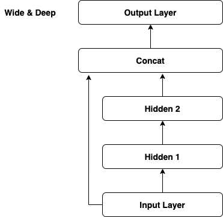

```python
Image(filename='img/MLP_1.png')
```

```python
input_ = keras.layers.Input(shape=X_train.shape[1:])
hidden1 = keras.layers.Dense(30, activation="relu")(input_)
hidden2 = keras.layers.Dense(30, activation="relu")(hidden1)
concat = keras.layers.concatenate([input_, hidden2])
output = keras.layers.Dense(1)(concat)
model = keras.models.Model(inputs=[input_], outputs=[output])
```

```python
model.compile(loss="mean_squared_error", optimizer=keras.optimizers.SGD(lr=1e-3))
history = model.fit(X_train, y_train, epochs=20, validation_data=(X_valid, y_valid))
```

```python
y_pred = model.predict(X_test[:3])
y_pred
```

```
array([[0.4701073],
       [1.8735044],
       [3.379823 ]], dtype=float32)
```

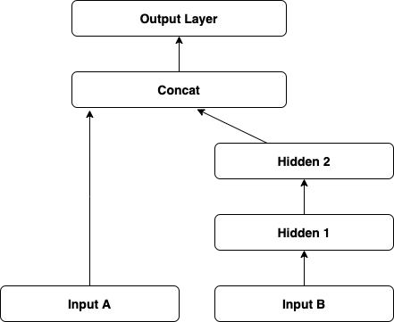

```python
Image(filename='img/MLP_2.png')
```

```python
X_train_A, X_train_B = X_train[:, :5], X_train[:, 2:]
X_valid_A, X_valid_B = X_valid[:, :5], X_valid[:, 2:]
X_test_A, X_test_B = X_test[:, :5], X_test[:, 2:]
X_new_A, X_new_B = X_test_A[:3], X_test_B[:3]
```

```python
input_A = keras.layers.Input(shape=[5], name="wide_input")
input_B = keras.layers.Input(shape=[6], name="deep_input")
hidden1 = keras.layers.Dense(30, activation="relu")(input_B)
hidden2 = keras.layers.Dense(30, activation="relu")(hidden1)
concat = keras.layers.concatenate([input_A, hidden2])
output = keras.layers.Dense(1, name="main_output")(concat)

model = keras.models.Model(inputs=[input_A, input_B],outputs=[output])
model.compile(loss="mse", optimizer=keras.optimizers.SGD(lr=1e-3))
```

```python
history = model.fit((X_train_A, X_train_B), y_train, epochs=20)
```

```python
model.predict((X_new_A, X_new_B))
```

```
array([[0.40118584],
       [1.9036655 ],
       [3.3729222 ]], dtype=float32)
```

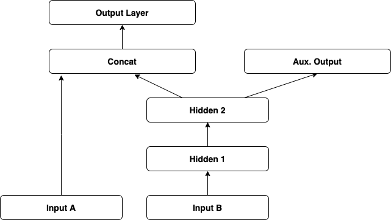

```python
Image(filename='img/MLP_3.png')
```

```python
input_A = keras.layers.Input(shape=[5], name="wide_input")
input_B = keras.layers.Input(shape=[6], name="deep_input")
hidden1 = keras.layers.Dense(30, activation="relu")(input_B)
hidden2 = keras.layers.Dense(30, activation="relu")(hidden1)
concat = keras.layers.concatenate([input_A, hidden2])
output = keras.layers.Dense(1, name="main_output")(concat)
aux_output = keras.layers.Dense(1, name="aux_output")(hidden2)
model = keras.models.Model(inputs=[input_A, input_B],outputs=[output, aux_output])
```

```python
# by default, the final loss used for training is the sum of all losses
# auxiliary is used as regularization
# main output has higher weight than auxiliary output
model.compile(loss=["mse", "mse"], loss_weights=[0.9, 0.1], optimizer=keras.optimizers.SGD(lr=1e-3))
```

```python
history = model.fit([X_train_A, X_train_B], [y_train, y_train], epochs=20,
                    validation_data=([X_valid_A, X_valid_B], [y_valid, y_valid]))
```

```python
total_loss, main_loss, aux_loss = model.evaluate([X_test_A, X_test_B], [y_test, y_test])
```

```python
y_pred_main, y_pred_aux = model.predict([X_new_A, X_new_B])
```

#### Subclassing API

- Model's architecture is hidden within the call() method
- Cannot easily inspect it with Keras
- Lose the information about how layers are connected to each other

```python
class WideAndDeepModel(keras.models.Model):
    def __init__(self, units=30, activation="relu", **kwargs):
        """Create layters"""
        super().__init__(**kwargs)
        self.hidden1 = keras.layers.Dense(units, activation=activation)
        self.hidden2 = keras.layers.Dense(units, activation=activation)
        self.main_output = keras.layers.Dense(1)
        self.aux_output = keras.layers.Dense(1)

    def call(self, inputs):
        """Create architecture and conduct operations"""
        input_A, input_B = inputs
        #print(len(inputs))
        hidden1 = self.hidden1(input_B)
        hidden2 = self.hidden2(hidden1)
        concat = keras.layers.concatenate([input_A, hidden2])
        main_output = self.main_output(concat)
        aux_output = self.aux_output(hidden2)
        return main_output, aux_output

model = WideAndDeepModel(30, activation="relu")
```

```python
model.compile(loss="mse", loss_weights=[0.9, 0.1], optimizer=keras.optimizers.SGD(lr=1e-3))
history = model.fit((X_train_A, X_train_B), (y_train, y_train), epochs=10, validation_data=((X_valid_A, X_valid_B), (y_valid, y_valid)))
```

#### Save and Restore a Model

```python
# save subclass model
# cannot be saved in h5 format
model.save('temp_model', save_format='tf') # save model
model_load = keras.models.load_model('temp_model')
```

```
INFO:tensorflow:Assets written to: temp_model/assets
```

```python
# save a model created with Sequential or Functional API
model.save('temp.h5') # save model
model_load = keras.models.load_model('temp.h5')
```

```python
total_loss, main_loss, aux_loss = model_load.evaluate((X_test_A, X_test_B), (y_test, y_test))
y_pred_main, y_pred_aux = model_load.predict((X_new_A, X_new_B))
```

#### Using Callbacks

- Training, fit()
  - on_train_begin(), on_train_end()
  - on_epoch_begin(), on_epoch_end()
  - on_batch_begin(), on_batch_end()
- Evaluation, evaluate()
  - on_test_begin(), on_test_end()
  - on_test_batch_begin(), on_tesst_batch_end()
- Prediction, predict()
  - on_predict_begin(), on_predict_end()
  - on_predict_batch_begin(), on_predict_batch_end()

```python
housing = fetch_california_housing()

X_train_full, X_test, y_train_full, y_test = train_test_split(housing.data, housing.target, random_state=42)
X_train, X_valid, y_train, y_valid = train_test_split(X_train_full, y_train_full, random_state=42)

scaler = StandardScaler()
X_train = scaler.fit_transform(X_train)
X_valid = scaler.transform(X_valid)
X_test = scaler.transform(X_test)
```

```python
input_ = keras.layers.Input(shape=X_train.shape[1:])
hidden1 = keras.layers.Dense(30, activation="relu")(input_)
hidden2 = keras.layers.Dense(30, activation="relu")(hidden1)
concat = keras.layers.concatenate([input_, hidden2])
output = keras.layers.Dense(1)(concat)
model = keras.models.Model(inputs=[input_], outputs=[output])
```

```python
class PrintValTrainRatioCallback(keras.callbacks.Callback):
    def on_epoch_end(self, epoch, logs):
        print(logs['val_loss']/logs['loss'])
```

```python
model.compile(loss="mean_squared_error", optimizer=keras.optimizers.SGD(lr=1e-3))
history = model.fit(X_train, y_train, epochs=20, validation_data=(X_valid, y_valid), callbacks=[PrintValTrainRatioCallback()])
```

#### Early Stop

- EarlyStopping callback keep track of the best weights and restore them at the end of training

```python
early_stopping_cb = keras.callbacks.EarlyStopping(patience=10, restore_best_weights=True)
history = model.fit(X_train, y_train, epochs=100, validation_data=(X_valid, y_valid), callbacks=[early_stopping_cb])
```

#### Check points

```python
checkpoint_cb = keras.callbacks.ModelCheckpoint('my_keras_model.h5', save_best_only=True)
history = model.fit(X_train, y_train, epochs=100, validation_data=(X_valid, y_valid), callbacks=[checkpoint_cb])
```

```python
model = keras.models.load_model('my_keras_model.h5') # roll back to best model
```

#### TensorBoard

```python
fashion_mnist = keras.datasets.fashion_mnist
(X_train, y_train), (X_test, y_test) = fashion_mnist.load_data()
```

```python
X_valid, X_train = X_train[:5000] / 255., X_train[5000:] / 255.
y_valid, y_train = y_train[:5000], y_train[5000:]
X_test = X_test / 255.
```

```python
import os
import time
def get_run_logdir():
    run_id = time.strftime("run_%Y_%m_%d-%H_%M_%S")
    return os.path.join('log', run_id)

run_logdir = get_run_logdir()
```

```python
# MLP Classification
model = keras.models.Sequential()
model.add(keras.layers.Flatten(input_shape=[28, 28])) # convert input image into a 1D array
model.add(keras.layers.Dense(300, activation='relu')) # contain connection weights between neurons and their inputs, bias
model.add(keras.layers.Dense(100, activation='relu'))
model.add(keras.layers.Dense(10, activation='softmax'))
model.compile(loss='sparse_categorical_crossentropy', optimizer='sgd', metrics=['accuracy'])
```

```python
tensorboard_cb = keras.callbacks.TensorBoard(run_logdir)
history = model.fit(X_train, y_train, epochs=30, validation_data=(X_valid, y_valid), callbacks=[tensorboard_cb])
```

```python
%load_ext tensorboard
%tensorboard --logdir=./log --port=6006
```

#### Fine-Tuning Libraries

- [Hyperopt](https://github.com/hyperopt/hyperopt)
- [Hyperas](https://github.com/maxpumperla/hyperas)
- kopt
- [Talos](https://github.com/autonomio/talos)
- [Keras Tuner](https://keras-team.github.io/keras-tuner/)
- [Scikit-Optimize](https://scikit-optimize.github.io/stable/)
- [Spearmint](https://github.com/JasperSnoek/spearmint)
- [Hyperband](https://github.com/zygmuntz/hyperband)
- [Sklearn-Deap](https://github.com/rsteca/sklearn-deap)

#### Fine-Tuning Services

- [Google Cloud AI Platform](https://cloud.google.com/ai-platform/training/docs/using-hyperparameter-tuning)
- [Arimo](https://arimo.com/)
- [SigOpt](https://sigopt.com/)
- [CallDesk's Oscar](http://oscar.calldesk.ai/)

#### Grid Search a Regression Model with Sklearn

```python
housing = fetch_california_housing()

X_train_full, X_test, y_train_full, y_test = train_test_split(housing.data, housing.target, random_state=42)
X_train, X_valid, y_train, y_valid = train_test_split(X_train_full, y_train_full, random_state=42)

scaler = StandardScaler()
X_train = scaler.fit_transform(X_train)
X_valid = scaler.transform(X_valid)
X_test = scaler.transform(X_test)
```

```python
def build_model(n_hidden=1, n_neurons=30, learning_rate=3e-3, input_shape=[8]):
    model = keras.models.Sequential()
    model.add(keras.layers.InputLayer(input_shape=input_shape))
    for layer in range(n_hidden):
        model.add(keras.layers.Dense(n_neurons, activation="relu"))
    model.add(keras.layers.Dense(1))
    optimizer = keras.optimizers.SGD(lr=learning_rate)
    model.compile(loss="mse", optimizer=optimizer)
    return model
```

```python
keras_reg = keras.wrappers.scikit_learn.KerasRegressor(build_model)
```

```python
from scipy.stats import reciprocal
from sklearn.model_selection import RandomizedSearchCV

param_distribs = {
    "n_hidden": [0, 1, 2, 3],
    "n_neurons": [10, 20],
    "learning_rate": [0.01, 0.02],
}

rnd_search_cv = RandomizedSearchCV(keras_reg, param_distribs, n_iter=10, cv=3, verbose=2)
rnd_search_cv.fit(X_train, y_train, epochs=10,
                  validation_data=(X_valid, y_valid),
                  callbacks=[keras.callbacks.EarlyStopping(patience=10)])
```

```python
print(rnd_search_cv.best_params_)
print(rnd_search_cv.best_score_)
```

```
{'n_neurons': 20, 'n_hidden': 2, 'learning_rate': 0.01}
-0.3620850046475728
```

```python
model = rnd_search_cv.best_estimator_.model
model.predict(X_test)
```

```
array([[0.85256857],
       [1.6229372 ],
       [3.9205074 ],
       ...,
       [1.5167751 ],
       [2.5552483 ],
       [3.9521298 ]], dtype=float32)
```

#### Grid Search a Classification Model with Sklearn

```python
(X_train, y_train), (X_test, y_test) = fashion_mnist.load_data()

X_valid, X_train = X_train[:5000] / 255., X_train[5000:] / 255.
y_valid, y_train = y_train[:5000], y_train[5000:]
X_test = X_test / 255.
```

```python
# create a funciton to build and compile a Keras model
def build_model(n_hidden=1, n_neurons=30, learning_rate=3e-3):
    model = keras.models.Sequential()
    model.add(keras.layers.Flatten(input_shape=[28, 28])) # convert input image into a 1D array
    for layer in range(n_hidden):
        model.add(keras.layers.Dense(n_neurons, activation='relu'))
    model.add(keras.layers.Dense(10, activation='softmax'))
    model.compile(loss='sparse_categorical_crossentropy', optimizer='sgd', metrics=['accuracy'])
    return model
```

```python
# create a sklearn wrapper, convert a Keras model to a Scikit-learn model
keras_clf = keras.wrappers.scikit_learn.KerasClassifier(build_model)
```

```python
# cross-validation
# sklearn above 0.21 may cause clone error
import numpy as np
from sklearn.model_selection import RandomizedSearchCV

param_distribs = {
    'n_hidden': [1],
    'n_neurons': [10, 20],
    'learning_rate': [3e-4]
}
```

```python
rnd_search_cv = RandomizedSearchCV(keras_clf, param_distribs, n_iter=3, cv=3)
rnd_search_cv.fit(X_train, y_train, epochs=10)
```

```python
print(rnd_search_cv.best_params_)
```

```
{'n_neurons': 20, 'n_hidden': 1, 'learning_rate': 0.0003}
```

```python
model = rnd_search_cv.best_estimator_.model
model.predict(X_test)
```

#### Hyperparameter Selection

- 1. Learning rate
     - the optimal learning rate is about half of the maximum learning rate which makes the training algorithm diverges
     - optimal learning rate depends on the other hyperparameters, especially the batch size
- 1. Optimizer
- 1. Number of layers
     - one hidden layer having enough neurons can theoretically model even the most complex functions
     - lower hidden layers model low-level structures, e.g. line segments of various shapes and orientations
     - intermediate hidden layers combine low-level structures to model intermediate-level structures, e.g. squares, circles
     - highest hidden layers and the output layer conbine intermediate structures to model high-level structures, e.g. faces
     - ramp up the number of hidden layers until overfitting the training set
     - Reusing parts of apretrained state-of-the-art network will be faster and reuqures much less data
- 1. Number of neurons per layer, activation function
     - form a pyramid, with fewer and fewer neurons at each layer
     - using the same number of neurons in all hidden layers performs well in most cases, or even better
     - sometimes help to make the first hidden layer bigger than the others
     - pick more layers and neurons than you need, then use ealy stopping and other regularization techniques to prevent it from overfitting
     - in general, increase the number of layers instead of the number of neurons per layer
- 1. Activation functions
     - ReLU is a good default for all hidden layers
     - depends on tasks for the output layer
- 1. Batch size
     - use a large batch size, use learning rate warmup, if unstable or the final performance is disppointing, use small batch size, such as 32 tweeted by Yann LeCun
- 1. Number of iterations
     - Does not actually need to be tweaked, just use early stopping instead

#### Reference

- [Tuning Neural Network Hyperparameters](https://arxiv.org/abs/1803.09820)
- [Tensorflow Keras](https://www.tensorflow.org/api_docs/python/tf/keras)
- [Activation Functions](https://keras.io/api/layers/activations/)
- [Initializers](https://keras.io/api/layers/initializers/)
- [Loss Function](https://keras.io/api/losses/)
- [Optimizers](https://keras.io/api/optimizers/)
- [Metrics](https://keras.io/api/metrics/)
- [Tensorflow Playground](https://playground.tensorflow.org/)